# Course Project: Practical Machine Learning

Natalia clivio

Saturday, August 24, 2014

## Introduction

The objective of this analysis is to predict the manner in which six participants did the exercise. They performed the excercise in five different ways; one exactly follows the specification, and the other four follow the specification incorrect way. The data for this project come from this source: http://groupware.les.inf.puc-rio.br/har

## Data Preparation

It is important to prepare the data to obtain more accurate results.

```r
#Load Data splitting
library(caret)
library(ISLR)

training <-read.csv("C:/Users/NataliaA/Desktop/CourseaR/pml-training.csv")
testing <-read.csv("C:/Users/NataliaA/Desktop/CourseaR/pml-testing.csv")

# remove near zero covariates
nsv <- nearZeroVar(training, saveMetrics = TRUE)
training <- training[, !nsv$nzv]

# remove variables with more than 80% missing values
nav <- sapply(colnames(training), function(x) if(sum(is.na(training[, x])) > 0.8*nrow(training)){return(T)}else{return(F)})
training <- training[, !nav]

# calculate correlations
cor <- abs(sapply(colnames(training[, -ncol(training)]), function(x) cor(as.numeric(training[, x]), as.numeric(training$classe), method = "spearman")))
summary(cor)
```

```
##    Min. 1st Qu.  Median    Mean 3rd Qu.    Max.
##  0.0015  0.0147  0.0526  0.1020  0.1390  0.9770
```

Plot the variables more correlationed with the **classe** variable in the training set data, are showed in the following figure:

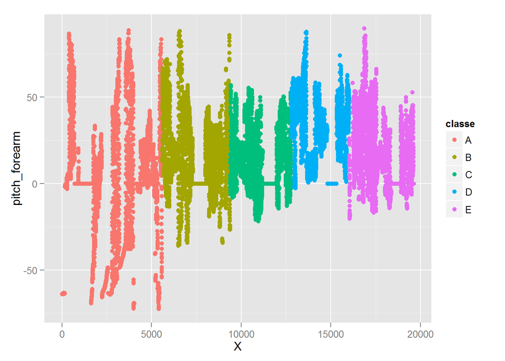

Then the Random forest and Bosting algorithms are compared to determine which is more accurate and makes final predictions.

## Random Forest

```r
library(randomForest)
set.seed(123)
modFitrf <- train(classe ~ ., method = "rf", data = training, importance = TRUE, trControl = trainControl(method = "cv", number = 10))

modFitrf
```

[output not shown]

The accurancy of the model is:

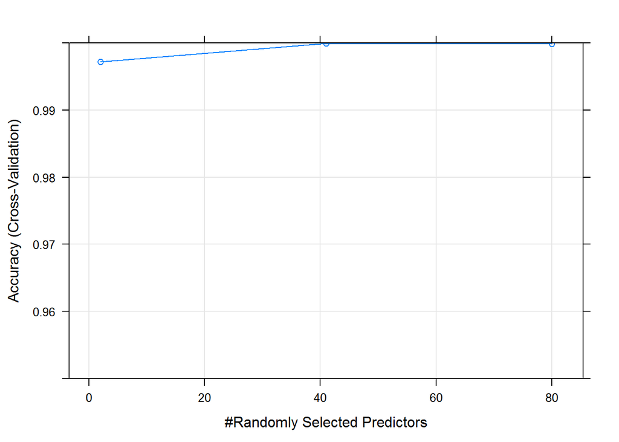

```r
plot(modFitrf, ylim = c(0.95, 1))
```

*Figure 1*

The random forests algorithm generated has a very accurate model with accuracy close to 1.